# Part I - (Ford GoBike System Data Exploration)

## Introduction

> This data set includes information about individual rides made in a bike-sharing system covering the greater San Francisco Bay area. The features included in the dataset : Trip Duration (seconds) , Start Time and Date , End Time and Date , Start Station ID , Start Station Name , Start Station Latitude , Start Station Longitude , End Station ID , End Station Name, End Station Latitude , End Station Longitude , Bike ID , User Type (Subscriber or Customer – “Subscriber” = Member or “Customer” = Casual) , Member Year of Birth, Member Gender

## Preliminary Wrangling

```python
# import all packages and set plots to be embedded inline
import numpy as np
import pandas as pd
import matplotlib.pyplot as plt
import seaborn as sb

%matplotlib inline
```

> Load in your dataset and describe its properties through the questions below. Try and motivate your exploration goals through this section.

```python
df = pd.read_csv('201902-fordgobike-tripdata.csv')
```

Data OverView

```python
df.head()
```

|  | duration_sec | start_time | end_time | start_station_id | start_station_name | start_station_latitude | start_station_longitude | end_station_id | end_station_name | end_station_latitude | end_station_longitude | bike_id | user_type | member_birth_year | member_gender | bike_share_for_all_trip |
| --- | --- | --- | --- | --- | --- | --- | --- | --- | --- | --- | --- | --- | --- | --- | --- | --- |
| 0 | 52185 | 2019-02-28 17:32:10.1450 | 2019-03-01 08:01:55.9750 | 21.0 | Montgomery St BART Station (Market St at 2nd St) | 37.789625 | -122.400811 | 13.0 | Commercial St at Montgomery St | 37.794231 | -122.402923 | 4902 | Customer | 1984.0 | Male | No |
| 1 | 42521 | 2019-02-28 18:53:21.7890 | 2019-03-01 06:42:03.0560 | 23.0 | The Embarcadero at Steuart St | 37.791464 | -122.391034 | 81.0 | Berry St at 4th St | 37.775880 | -122.393170 | 2535 | Customer | NaN | NaN | No |
| 2 | 61854 | 2019-02-28 12:13:13.2180 | 2019-03-01 05:24:08.1460 | 86.0 | Market St at Dolores St | 37.769305 | -122.426826 | 3.0 | Powell St BART Station (Market St at 4th St) | 37.786375 | -122.404904 | 5905 | Customer | 1972.0 | Male | No |
| 3 | 36490 | 2019-02-28 17:54:26.0100 | 2019-03-01 04:02:36.8420 | 375.0 | Grove St at Masonic Ave | 37.774836 | -122.446546 | 70.0 | Central Ave at Fell St | 37.773311 | -122.444293 | 6638 | Subscriber | 1989.0 | Other | No |
| 4 | 1585 | 2019-02-28 23:54:18.5490 | 2019-03-01 00:20:44.0740 | 7.0 | Frank H Ogawa Plaza | 37.804562 | -122.271738 | 222.0 | 10th Ave at E 15th St | 37.792714 | -122.248780 | 4898 | Subscriber | 1974.0 | Male | Yes |

```python
df.shape
```

```
(183412, 16)
```

```python
df.info()
```

```
<class 'pandas.core.frame.DataFrame'>
RangeIndex: 183412 entries, 0 to 183411
Data columns (total 16 columns):
 #   Column                   Non-Null Count   Dtype
---  ------                   --------------   -----
 0   duration_sec             183412 non-null  int64
 1   start_time               183412 non-null  object
 2   end_time                 183412 non-null  object
 3   start_station_id         183215 non-null  float64
 4   start_station_name       183215 non-null  object
 5   start_station_latitude   183412 non-null  float64
 6   start_station_longitude  183412 non-null  float64
 7   end_station_id           183215 non-null  float64
 8   end_station_name         183215 non-null  object
 9   end_station_latitude     183412 non-null  float64
 10  end_station_longitude    183412 non-null  float64
 11  bike_id                  183412 non-null  int64
 12  user_type                183412 non-null  object
 13  member_birth_year        175147 non-null  float64
 14  member_gender            175147 non-null  object
 15  bike_share_for_all_trip  183412 non-null  object
dtypes: float64(7), int64(2), object(7)
memory usage: 22.4+ MB
```

check for missing data and deal with this issue:

```python
df.isnull().sum()
```

```
duration_sec                  0
start_time                    0
end_time                      0
start_station_id            197
start_station_name          197
start_station_latitude        0
start_station_longitude       0
end_station_id              197
end_station_name            197
end_station_latitude          0
end_station_longitude         0
bike_id                       0
user_type                     0
member_birth_year          8265
member_gender              8265
bike_share_for_all_trip       0
dtype: int64
```

```python
# here all the missing values were dropped since no source of data could be found to fill the missing values
df.dropna(inplace = True)
df.isnull().sum()
```

```
duration_sec               0
start_time                 0
end_time                   0
start_station_id           0
start_station_name         0
start_station_latitude     0
start_station_longitude    0
end_station_id             0
end_station_name           0
end_station_latitude       0
end_station_longitude      0
bike_id                    0
user_type                  0
member_birth_year          0
member_gender              0
bike_share_for_all_trip    0
dtype: int64
```

check for duplicated rows and drop them if they exist:

```python
#NO duplicated data were found
sum(df.duplicated())
```

```
0
```

Next the unwanted columns well be dropped:

```python
df.info()
```

```
<class 'pandas.core.frame.DataFrame'>
Int64Index: 174952 entries, 0 to 183411
Data columns (total 16 columns):
 #   Column                   Non-Null Count   Dtype
---  ------                   --------------   -----
 0   duration_sec             174952 non-null  int64
 1   start_time               174952 non-null  object
 2   end_time                 174952 non-null  object
 3   start_station_id         174952 non-null  float64
 4   start_station_name       174952 non-null  object
 5   start_station_latitude   174952 non-null  float64
 6   start_station_longitude  174952 non-null  float64
 7   end_station_id           174952 non-null  float64
 8   end_station_name         174952 non-null  object
 9   end_station_latitude     174952 non-null  float64
 10  end_station_longitude    174952 non-null  float64
 11  bike_id                  174952 non-null  int64
 12  user_type                174952 non-null  object
 13  member_birth_year        174952 non-null  float64
 14  member_gender            174952 non-null  object
 15  bike_share_for_all_trip  174952 non-null  object
dtypes: float64(7), int64(2), object(7)
memory usage: 22.7+ MB
```

```python
df.drop(['start_station_latitude','start_station_longitude', 'end_station_latitude', 'end_station_longitude'], axis = 1, inplace = True)
df.info()
```

```
<class 'pandas.core.frame.DataFrame'>
Int64Index: 174952 entries, 0 to 183411
Data columns (total 12 columns):
 #   Column                   Non-Null Count   Dtype
---  ------                   --------------   -----
 0   duration_sec             174952 non-null  int64
 1   start_time               174952 non-null  object
 2   end_time                 174952 non-null  object
 3   start_station_id         174952 non-null  float64
 4   start_station_name       174952 non-null  object
 5   end_station_id           174952 non-null  float64
 6   end_station_name         174952 non-null  object
 7   bike_id                  174952 non-null  int64
 8   user_type                174952 non-null  object
 9   member_birth_year        174952 non-null  float64
 10  member_gender            174952 non-null  object
 11  bike_share_for_all_trip  174952 non-null  object
dtypes: float64(3), int64(2), object(7)
memory usage: 17.4+ MB
```

```python
df.head()
```

|  | duration_sec | start_time | end_time | start_station_id | start_station_name | end_station_id | end_station_name | bike_id | user_type | member_birth_year | member_gender | bike_share_for_all_trip |
| --- | --- | --- | --- | --- | --- | --- | --- | --- | --- | --- | --- | --- |
| 0 | 52185 | 2019-02-28 17:32:10.1450 | 2019-03-01 08:01:55.9750 | 21.0 | Montgomery St BART Station (Market St at 2nd St) | 13.0 | Commercial St at Montgomery St | 4902 | Customer | 1984.0 | Male | No |
| 2 | 61854 | 2019-02-28 12:13:13.2180 | 2019-03-01 05:24:08.1460 | 86.0 | Market St at Dolores St | 3.0 | Powell St BART Station (Market St at 4th St) | 5905 | Customer | 1972.0 | Male | No |
| 3 | 36490 | 2019-02-28 17:54:26.0100 | 2019-03-01 04:02:36.8420 | 375.0 | Grove St at Masonic Ave | 70.0 | Central Ave at Fell St | 6638 | Subscriber | 1989.0 | Other | No |
| 4 | 1585 | 2019-02-28 23:54:18.5490 | 2019-03-01 00:20:44.0740 | 7.0 | Frank H Ogawa Plaza | 222.0 | 10th Ave at E 15th St | 4898 | Subscriber | 1974.0 | Male | Yes |
| 5 | 1793 | 2019-02-28 23:49:58.6320 | 2019-03-01 00:19:51.7600 | 93.0 | 4th St at Mission Bay Blvd S | 323.0 | Broadway at Kearny | 5200 | Subscriber | 1959.0 | Male | No |

Lets add a column for trip duration in minuets

```python
df['duration_min'] = df['duration_sec']/60
df.head()
```

|  | duration_sec | start_time | end_time | start_station_id | start_station_name | end_station_id | end_station_name | bike_id | user_type | member_birth_year | member_gender | bike_share_for_all_trip | duration_min |
| --- | --- | --- | --- | --- | --- | --- | --- | --- | --- | --- | --- | --- | --- |
| 0 | 52185 | 2019-02-28 17:32:10.1450 | 2019-03-01 08:01:55.9750 | 21.0 | Montgomery St BART Station (Market St at 2nd St) | 13.0 | Commercial St at Montgomery St | 4902 | Customer | 1984.0 | Male | No | 869.750000 |
| 2 | 61854 | 2019-02-28 12:13:13.2180 | 2019-03-01 05:24:08.1460 | 86.0 | Market St at Dolores St | 3.0 | Powell St BART Station (Market St at 4th St) | 5905 | Customer | 1972.0 | Male | No | 1030.900000 |
| 3 | 36490 | 2019-02-28 17:54:26.0100 | 2019-03-01 04:02:36.8420 | 375.0 | Grove St at Masonic Ave | 70.0 | Central Ave at Fell St | 6638 | Subscriber | 1989.0 | Other | No | 608.166667 |
| 4 | 1585 | 2019-02-28 23:54:18.5490 | 2019-03-01 00:20:44.0740 | 7.0 | Frank H Ogawa Plaza | 222.0 | 10th Ave at E 15th St | 4898 | Subscriber | 1974.0 | Male | Yes | 26.416667 |
| 5 | 1793 | 2019-02-28 23:49:58.6320 | 2019-03-01 00:19:51.7600 | 93.0 | 4th St at Mission Bay Blvd S | 323.0 | Broadway at Kearny | 5200 | Subscriber | 1959.0 | Male | No | 29.883333 |

next I will break down the start_time column into three columns that will be shown below

```python
df['start_time'] =  pd.to_datetime(df['start_time'])
df['start_date'] = df.start_time.dt.strftime('%Y-%m-%d')
df['hour_of_day'] = df.start_time.dt.strftime('%H')
df['day_of_week'] = df.start_time.dt.strftime('%A')
df['month'] = df.start_time.dt.strftime('%B')
```

```python
df.to_csv('Data_Clean.csv')
```

Data Overview after Wrangling

```python
df.head()
```

|  | duration_sec | start_time | end_time | start_station_id | start_station_name | end_station_id | end_station_name | bike_id | user_type | member_birth_year | member_gender | bike_share_for_all_trip | duration_min | start_date | hour_of_day | day_of_week | month |
| --- | --- | --- | --- | --- | --- | --- | --- | --- | --- | --- | --- | --- | --- | --- | --- | --- | --- |
| 0 | 52185 | 2019-02-28 17:32:10.145 | 2019-03-01 08:01:55.9750 | 21.0 | Montgomery St BART Station (Market St at 2nd St) | 13.0 | Commercial St at Montgomery St | 4902 | Customer | 1984.0 | Male | No | 869.750000 | 2019-02-28 | 17 | Thursday | February |
| 2 | 61854 | 2019-02-28 12:13:13.218 | 2019-03-01 05:24:08.1460 | 86.0 | Market St at Dolores St | 3.0 | Powell St BART Station (Market St at 4th St) | 5905 | Customer | 1972.0 | Male | No | 1030.900000 | 2019-02-28 | 12 | Thursday | February |
| 3 | 36490 | 2019-02-28 17:54:26.010 | 2019-03-01 04:02:36.8420 | 375.0 | Grove St at Masonic Ave | 70.0 | Central Ave at Fell St | 6638 | Subscriber | 1989.0 | Other | No | 608.166667 | 2019-02-28 | 17 | Thursday | February |
| 4 | 1585 | 2019-02-28 23:54:18.549 | 2019-03-01 00:20:44.0740 | 7.0 | Frank H Ogawa Plaza | 222.0 | 10th Ave at E 15th St | 4898 | Subscriber | 1974.0 | Male | Yes | 26.416667 | 2019-02-28 | 23 | Thursday | February |
| 5 | 1793 | 2019-02-28 23:49:58.632 | 2019-03-01 00:19:51.7600 | 93.0 | 4th St at Mission Bay Blvd S | 323.0 | Broadway at Kearny | 5200 | Subscriber | 1959.0 | Male | No | 29.883333 | 2019-02-28 | 23 | Thursday | February |

### Main feature(s) of interest in your dataset

> Trip Duration , Start Time and Date , End Time and Date, User Type , Member Year of Birth , Member Gender

### Features in the dataset that will help support our investigation into our feature(s) of interest

> 1) How long does the average trip take?

> 2) do most users have bike share for all trip?

> 3) Which gender used most ford bike?

> 4) what is the most common hour of the day that people ride bikes?

> 5) What are the most popular start and end stations?

> 6) Does the trip duration depend upon if a user is a subscriber or customer?

> 7) Does the trip duration depend upon gender?

> 8) What gender has the has the most subscribers?

> 9) Does member gender affect having bike share for all trip?

> 10) Is there a relationship between user type and hour of the day?

> 11) Does the trip duration depends on user type and gender?

> 12) What is the average trip duration every day for each gender?

## Univariate Exploration

How long does the average trip take?

since duration is a quantitaive data a histogram will be used

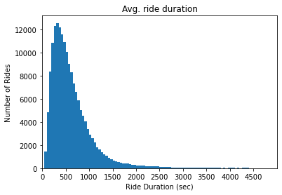

```python
bins = np.arange(0, df['duration_sec'].max() + 50, 50)
plt.hist(data = df, x = 'duration_sec', bins = bins);
plt.xlim(0,5000);
plt.xlabel('Ride Duration (sec)');
plt.xticks([0, 500, 1000, 1500, 2000, 2500, 3000, 3500, 4000, 4500]);
plt.ylabel('Number of Rides');
plt.title('Avg. ride duration');
```

as noted from the above plot most trips are small in distance so that the users reach their destination within 8 - 10 min (around 500 sec)

do most users have bike share for all trip?

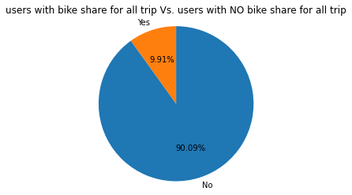

```python
plt.pie(df["bike_share_for_all_trip"].value_counts(), labels = df["bike_share_for_all_trip"].value_counts().index,
        startangle = 90,counterclock = False, autopct='%1.2f%%');
plt.axis('square')
plt.gca().set_aspect("equal")
plt.title('users with bike share for all trip Vs. users with NO bike share for all trip');
plt.ylabel('');
```

as noted from the above pie chart most users do not have bike share for all trip

Which gender used most ford bike?

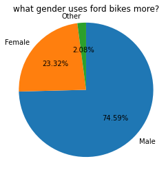

```python
plt.pie(df["member_gender"].value_counts(), labels = df["member_gender"].value_counts().index,
        startangle = 90,counterclock = False, autopct='%1.2f%%');
plt.axis('square')
plt.gca().set_aspect("equal")
plt.ylabel('');
plt.title('what gender uses ford bikes more?');
```

as seen from the above pie chart most members are males

```python
def myCountPlot (df, xVar, huevar, order=None,  palette=None) :
    '''
(their defaults are set)
docstring: IMPORTANT explain function here
inputs:
output:
'''
# set plot dimensions
    plt.figure (figsize=[14, 6])
# plot
    sb.countplot (data=df, x = xVar, hue=huevar, edgecolor='black' , order=order,palette=palette) ;
# OPTIONAL: AFTER plotting, clean up variable names
    xVar = xVar.replace("_", " ")
# replace _ with a space
    huevar=huevar.replace("_", " ")
# Add title and format it
    plt.title(f''' Distribution of {xVar} by {huevar}'''.title(), fontsize = 14, weight = "bold" )
# Add x label and format it
    plt.xlabel (xVar.title( ), fontsize = 10, weight = "bold")
# Add y label and format it
    plt.ylabel ('Frequency'.title(), fontsize = 10, weight = "bold" )
```

what is the most common hour of the day that people ride bikes?

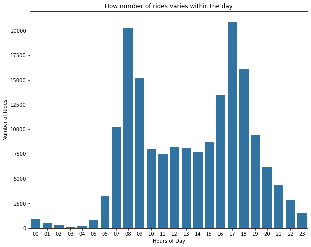

```python
ORDER = ['00', '01', '02', '03', '04', '05', '06', '07', '08', '09', '10', '11', '12', '13', '14', '15', '16', '17', '18', '19', '20', '21', '22', '23']
plt.figure(figsize = (10,8))
base_color = sb.color_palette()[0]
sb.countplot(data = df, x = 'hour_of_day', color = base_color, order = ORDER);
plt.xlabel('Hours of Day');
plt.ylabel('Number of Rides');
plt.title('How number of rides varies within the day');
```

we can notice that the 2 most common hours to start riding are 8 am and 5 pm which is predicted since at these times people go to work and leave work

What are the most popular start and end stations?

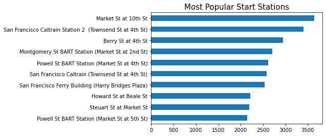

```python
plt.title('Most Popular Start Stations', fontsize=15)
df.start_station_name.value_counts(ascending=True).tail(10).plot.barh();
```

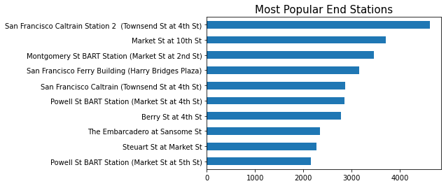

```python
plt.title('Most Popular End Stations', fontsize=15)
df.end_station_name.value_counts(ascending=True).tail(10).plot.barh();
```

> 1) it is noted that the most popular start station is: Market St at 10th St

> 2) it is noted that the most popular end station is: San Francisco Caltrain Station 2 (Townsend St at 4th St)

## Bivariate Exploration

Does the trip duration depend upon if a user is a subscriber or customer?

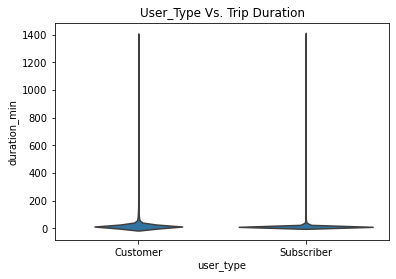

```python
base_color = sb.color_palette()[0]
sb.violinplot(data = df, x = 'user_type', y = 'duration_min', color = base_color, inner = None);
plt.title('User_Type Vs. Trip Duration');
```

## as seen above it is hard to see the difference because the output is dominated by outliers

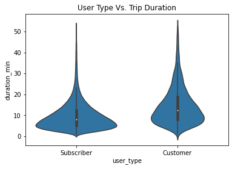

```python
sb. violinplot (data = df.query ('duration_min < duration_min.quantile (0.99) '), x = 'user_type', y = 'duration_min', color = base_color)
plt.title( 'User Type Vs. Trip Duration');
```

it is safe to say that on average a customer a slightly higher trip duration as shown above

Does the trip duration depend upon gender?

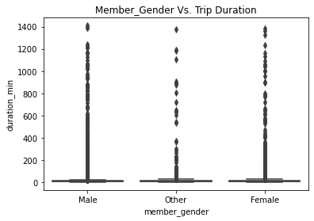

```python
base_color = sb.color_palette()[0]
sb.boxplot(data = df, x = 'member_gender', y = 'duration_min', color = base_color);
plt.title('Member_Gender Vs. Trip Duration');
```

## also here it is hard to determin anything from this plot because the output is dominated by outliers

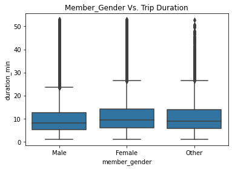

```python
sb.boxplot(data = df.query ('duration_min < duration_min.quantile (0.99) '), x = 'member_gender', y = 'duration_min', color = base_color);

plt.title('Member_Gender Vs. Trip Duration');
```

Noted from above on average Females and Others tend to have the highest trip duration

What gender has the has the most subscribers?

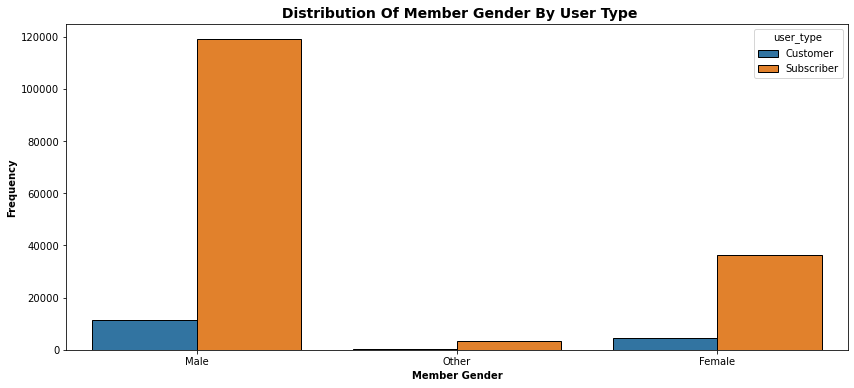

```python
myCountPlot(df, 'member_gender', 'user_type')
```

It is noted that Males are dominant in both User Types

Does member gender affect having bike share for all trip?

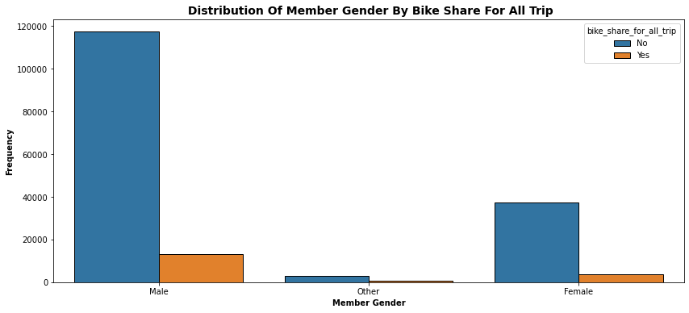

```python
myCountPlot(df, 'member_gender', 'bike_share_for_all_trip')
```

as noted from above useres of all genders tend to not use bike share for all trip

Is there a relationship between user type and hour of the day?

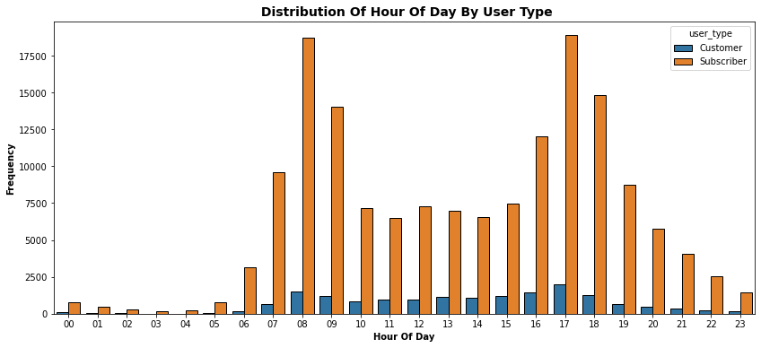

```python
ORDER = ['00', '01', '02', '03', '04', '05', '06', '07', '08', '09', '10', '11', '12', '13', '14', '15', '16', '17', '18', '19', '20', '21', '22', '23']
myCountPlot(df, 'hour_of_day', 'user_type', order = ORDER)
```

considering the above plot there is no obvious relationship between hour_of_day and user_type

### Relationships observed in this part of the investigation

> as said above the realtionships noted is that : a user type of costumer tend to have heigher trip duration that subscriber,also Females and Others have a heigher trip duration as well, moreover males have a heigher costumer and subscriber count

## Multivariate Exploration

does the trip duration depends on user type and gender?

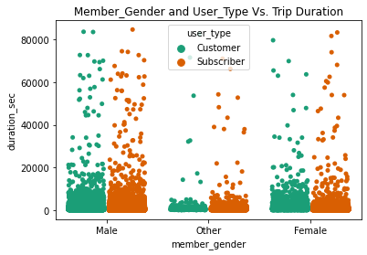

```python
sb.stripplot(x = "member_gender", y = "duration_sec", hue = 'user_type', data = df, jitter = 0.35, dodge = True, palette = "Dark2");
plt.title('Member_Gender and User_Type Vs. Trip Duration');
```

from the above plot the following was noted:

> 1) Male costumers and male subscribers has more counts of higher trip duration

> 2) Male subscribers have more counts of higher trip duration than male costumers

What is the average trip duration every day for each gender?

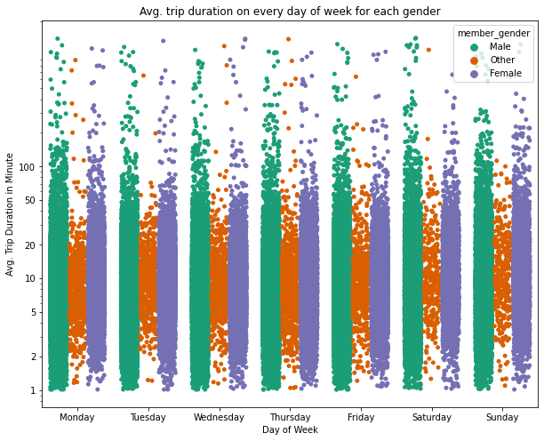

```python
plt.figure(figsize=(10,8))
day_order = ['Monday', 'Tuesday', 'Wednesday', 'Thursday', 'Friday', 'Saturday', 'Sunday']
sb.stripplot(x = "day_of_week", y = "duration_min", hue = 'member_gender', data = df, order = day_order, jitter = 0.35, dodge = True, palette = "Dark2");
plt.xlabel('Day of Week');
plt.ylabel('Avg. Trip Duration in Minute');
plt.yscale('log');
plt.yticks([1, 2, 5, 10, 20, 50, 100], [1, 2, 5, 10, 20, 50, 100]);
ax = plt.gca()
ax.set_yticklabels([],minor = True);
plt.title("Avg. trip duration on every day of week for each gender");
```

## Conclusions

> 1) It is clear now that Males used Ford Bike the most.

> 2) The hours that Ford Bike is mostly used is at 8 am and 5 pm which is predicted since at these times people go to work and leave work.

> 3) It was discovered that the most common start station is Market St at 10th St. And the most common end station is San Francisco Caltrain Station 2 (Townsend St at 4th St)